# Statistics with R: Introduction to Probability and Data

# Data Analysis Project: Exploring the BRFSS 2013 Dataset

*By Joseph Corliss*

## Setup

### Load packages

```r
library(ggplot2)
library(dplyr)
```

### Load data

```r
load("brfss2013.RData")
```

## Part 1: Data

In the 2013 BRFSS survey, responses were collected via randomly chosen “landline telephone- and cellular telephone-based surveys” [1] in all 50 US states, the District of Columbia, and several US territories and associated states including Puerto Rico, Guam, the US Virgin Islands, American Samoa, Federated States of Micronesia, and the country of Palau. Responses were only collected from non-institutionalized individuals aged 18 and older. In landline surveys, data is collected from a randomly chosen adult in the household.

Findings from the 2013 BRFSS survey can be generalized to “the non-institutionalized adult population, aged 18 years or older, who reside in the US” [1]. This generalization is possible because random sampling was performed on the stated population through random landline and cellular calls.

There are a few possible sources of bias in the data. One is non-response bias, that is, a bias introduced by some individuals not responding to the survey. Another is convenience bias: members of the population who do not own a cell phone, or who do not live in a household with a landline, cannot be reached by the survey [3].

We cannot draw causal links between observed variables because the BRFSS is an observational study, meaning that the researchers do not interfere with how the data arise via random assignment of the survey participants to different groups with different values of a chosen explanatory variable [2].

**References**

1. BRFSS Codebook: `brfss_codebook.html`
2. Introduction to Probability and Data video, “Observational Studies & Experiments”
3. Introduction to Probability and Data video, “Sampling and sources of bias”

## Part 2: Research questions

### Research quesion 1

Among non-institutionalized adults in the US, is increased fruit and vegetable intake associated with improved overall health? The answer to this question could shed light on whether a healthy diet should include lots of fruit and vegetables. The variables of interest are:

- `_frutsum` - Total Fruits Consumed Per Day
- `_vegesum` - Total Vegetables Consumed Per Day
- `genhlth` - General Health

### Research quesion 2

Among non-institutionalized adults in the US, we investigate any differences in alcohol comsumption between veterans and non-veterans. The results could indicate whether veterans are at a lower or higher risk of alcohol addiction. We note that respondents are likely to underreport their alcohol consumption, leading to a possible bias in the data. The variables of interest are:

- `veteran3`: Are You A Veteran
- `alcday5`: Days In Past 30 Had Alcoholic Beverage
- `avedrnk2`: Avg Alcoholic Drinks Per Day In Past 30

### Research quesion 3

Which states have the highest prevalence of smoking adults? In each state and US territory, we compare the percentage of respondents who currently smoke cigarettes. The variables of interest are:

- `_state`: State Fips Code
- `_rfsmok3`: Current Smoking Calculated Variable

## Part 3: Exploratory Data Analysis

### Research quesion 1

*Among non-institutionalized adults in the US, is increased fruit and vegetable intake associated with improved overall health? The answer to this question could shed light on whether a healthy diet should include lots of fruit and vegetables.*

First we use `group_by` together with `summarize` to view the value counts in the `genhlth` variable:

```r
brfss2013 %>%
  group_by(genhlth) %>%
  summarize(count = n())
```

```
## # A tibble: 6 x 2
##   genhlth    count
##   <fct>      <int>
## 1 Excellent  85482
## 2 Very good 159076
## 3 Good      150555
## 4 Fair       66726
## 5 Poor       27951
## 6 <NA>        1985
```

We see that there are 1985 missing values. Let’s visualize the general health values in a bar plot:

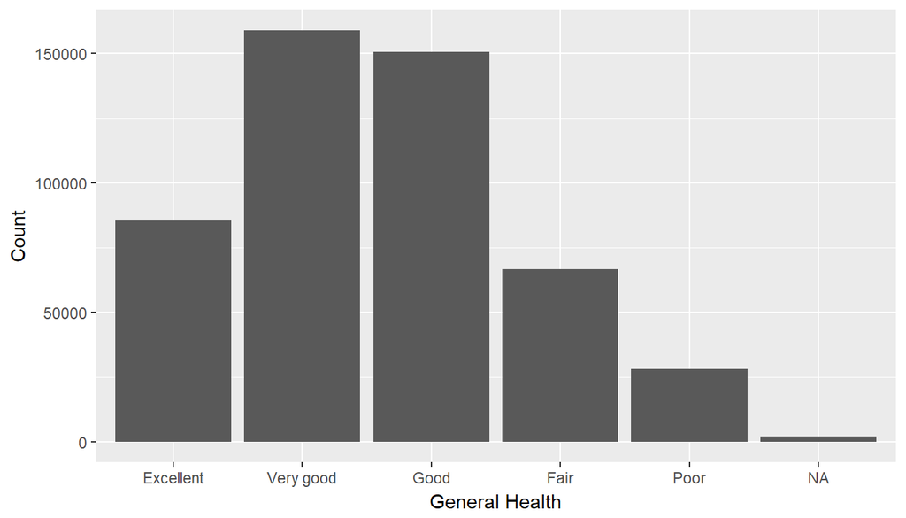

```r
ggplot(brfss2013, aes(x=genhlth)) + geom_bar() + xlab("General Health") + ylab("Count")
```

A majority of respondents consider their health to be either “Very good” or “Good.”

Next let’s explore the `_frutsum` and `_vegesum` variables. According to the Codebook, both `_vegesum` and `_frutsum` have 2 implied decimal places, meaning there should be a decimal point two places from the right end of each value. Let’s add this decimal point by dividing each variable by 100:

```r
brfss2013$X_frutsum = brfss2013$X_frutsum / 100
brfss2013$X_vegesum = brfss2013$X_vegesum / 100
```

Next let’s calculate summary statistics of `_vegesum` and `_frutsum`, after filtering out NA values. Starting with `_vegesum`:

```r
brfss2013 %>%
  filter(!is.na(X_vegesum)) %>%
  summarise(vegemean = mean(X_vegesum), vegemedian = median(X_vegesum), vegesd = sd(X_vegesum), vegemin = min(X_vegesum), vegemax = max(X_vegesum))
```

```
##   vegemean vegemedian   vegesd vegemin vegemax
## 1 1.900106       1.65 1.521421       0  198.27
```

Now we do the same for `_frutsum`:

```r
brfss2013 %>%
  filter(!is.na(X_frutsum)) %>%
  summarise(frutmean = mean(X_frutsum), frutmedian = median(X_frutsum), frutsd = sd(X_frutsum), frutmin = min(X_frutsum), frutmax = max(X_frutsum))
```

```
##   frutmean frutmedian   frutsd frutmin frutmax
## 1  1.39479       1.03 1.456998       0     198
```

Looking at the medians of `_vegesum` and `_frutsum`, a typical respondent eats 1.65 vegetables a day and 1.03 fruits per day. Both standard deviations are around 1.5, despite observed maxima of 198.27 for `_vegesum` and 198 for `_frutsum`.

Next we want to compute the total number of fruits and vegetables consumed. We do this by adding together `_frutsum` and `_vegesum` and storing the results in a new variable, `frutvegsum`:

```r
brfss2013$frutvegsum = brfss2013$X_frutsum + brfss2013$X_vegesum
```

Now let’s plot a histogram of `frutvegsum`. We ignore outliers by only including bins from 0 to 15.

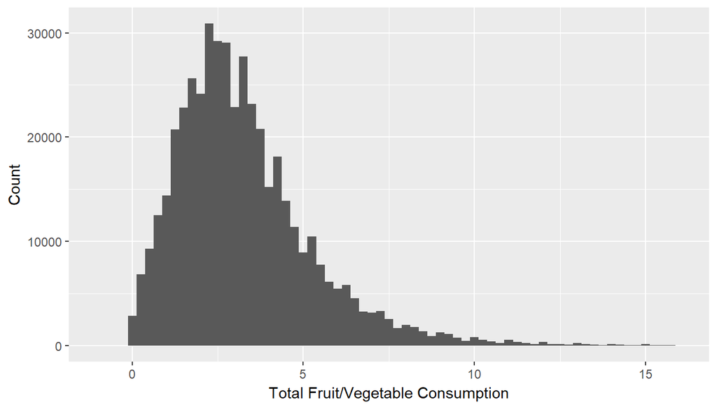

```r
ggplot(brfss2013, aes(x=frutvegsum)) + geom_histogram(binwidth=0.25) + xlim(-1, 16) + xlab("Total Fruit/Vegetable Consumption") + ylab("Count")
```

Now we address our ultimate research question: is there a relationship between fruit/vegetable consumption and overall health? We plot a separate boxplot of `frutvegsum` for each observed value of `genhlth`, once again neglecting outliers by setting the y-axis limits:

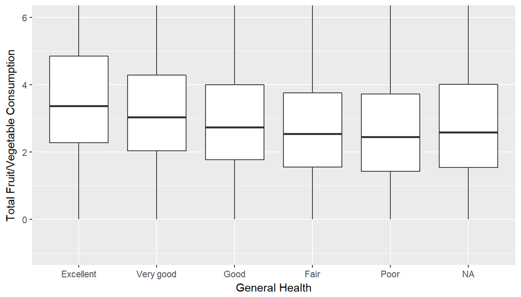

```r
brfss2013 %>%
  filter(!is.na(frutvegsum)) %>%
  ggplot(aes(x=genhlth, y=frutvegsum)) + geom_boxplot() + coord_cartesian(ylim=c(-1, 6)) + xlab("General Health") + ylab("Total Fruit/Vegetable Consumption")
```

We see that as general health improves from “Poor” to “Excellent,” there is a stepwise increase in the median fruit/vegetable consumption. We can investigate the median values in detail as follows:

```r
brfss2013 %>%
  filter(!is.na(frutvegsum)) %>%
  group_by(genhlth) %>%
  summarize(median_frutvegsum = median(frutvegsum))
```

```
## # A tibble: 6 x 2
##   genhlth   median_frutvegsum
##   <fct>                 <dbl>
## 1 Excellent              3.37
## 2 Very good              3.03
## 3 Good                   2.74
## 4 Fair                   2.54
## 5 Poor                   2.45
## 6 <NA>                   2.59
```

Our results suggest that eating more fruits and vegetables every day is associated with improved overall health. However, we cannot conclude that increasing or decreasing fruit/vegetable consumption will directly affect one’s overall health.

### Research quesion 2

*Among non-institutionalized adults in the US, we investigate any differences in alcohol comsumption between veterans and non-veterans. The results could indicate whether veterans are at a lower or higher risk of alcohol addiction. We note that respondents are likely to underreport their alcohol consumption, leading to a possible bias in the data.*

First let’s see the responses for veteran status:

```r
brfss2013 %>%
  group_by(veteran3) %>%
  summarize(count = n())
```

```
## # A tibble: 3 x 2
##   veteran3  count
##   <fct>     <int>
## 1 Yes       61446
## 2 No       429583
## 3 <NA>        746
```

What percentage of respondents are veterans?

```r
61446 / 429583
```

```
## [1] 0.1430364
```

The variable `alcday5` includes the frequency of alcohol consumption over the past 30 days. According to the Codebook, the first digit denotes days per week (1) or days per month (2), and the remaining digits indicate the count of days. We want to convert this variable to the number of days, over the last 30 days, that the respondent had an alcoholic beverage, and store the results in `alcday5_norm`:

```r
brfss2013 = brfss2013 %>%
  mutate(alcday5_norm = ifelse((alcday5 >= 101) & (alcday5 <= 199), (alcday5 - 100) * 30/7, ifelse((alcday5 >= 201) & (alcday5 <= 299), alcday5 - 200, alcday5)))
```

To check our work, let’s plot a histogram of `alcday5_norm`:

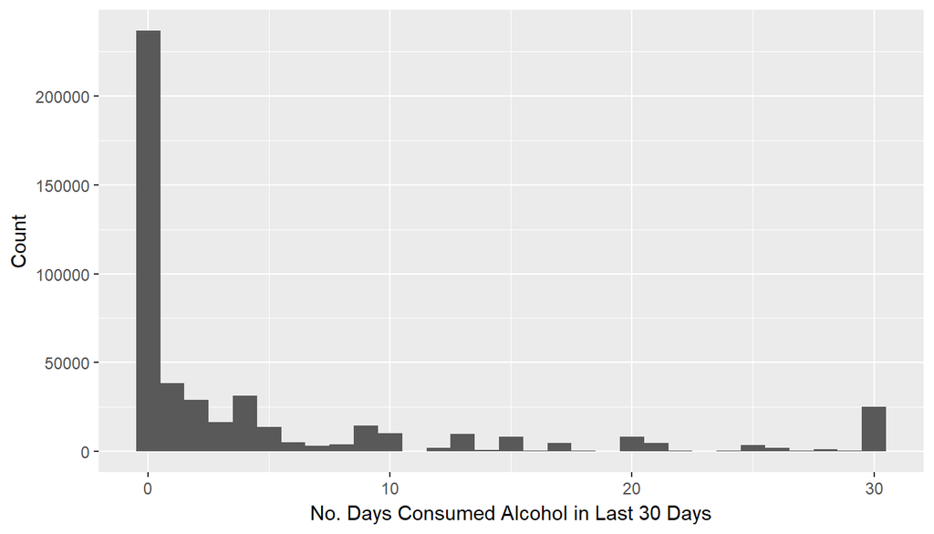

```r
ggplot(brfss2013, aes(x=alcday5_norm)) + geom_histogram(binwidth=1) + xlab("No. Days Consumed Alcohol in Last 30 Days") + ylab("Count")
```

We see that the majority of respondents did not drink at all during the last 30 days, with a minority drinking every single day over the last 30 days.

Next, to get the total number of drinks over the last 30 days, we multiply `alcday5_norm` and `avedrnk2`, and store the results in `drinks30days`:

```r
brfss2013 = brfss2013 %>%
  mutate(drinks30days = alcday5_norm * avedrnk2)
```

Now to address our research question, we compare summary statistics of `drinks30days` for veterans and non-veterans:

```r
brfss2013 %>%
  filter(!is.na(drinks30days)) %>%
  group_by(veteran3) %>%
  summarize(drinksmean = mean(drinks30days), drinksmedian = median(drinks30days), drinkssd = sd(drinks30days), drinksmin = min(drinks30days), drinksmax = max(drinks30days))
```

```
## # A tibble: 3 x 6
##   veteran3 drinksmean drinksmedian drinkssd drinksmin drinksmax
##   <fct>         <dbl>        <dbl>    <dbl>     <dbl>     <dbl>
## 1 Yes            29.1        12.9      54.8        1.     2280.
## 2 No             21.6         9.00     43.0        1.     2280.
## 3 <NA>           27.9         8.57     64.5        1.      600.
```

Comparing the means, we see that veterans drink 34% more than non-veterans on average. We can also compare boxplots of total drinks, separated by veteran status:

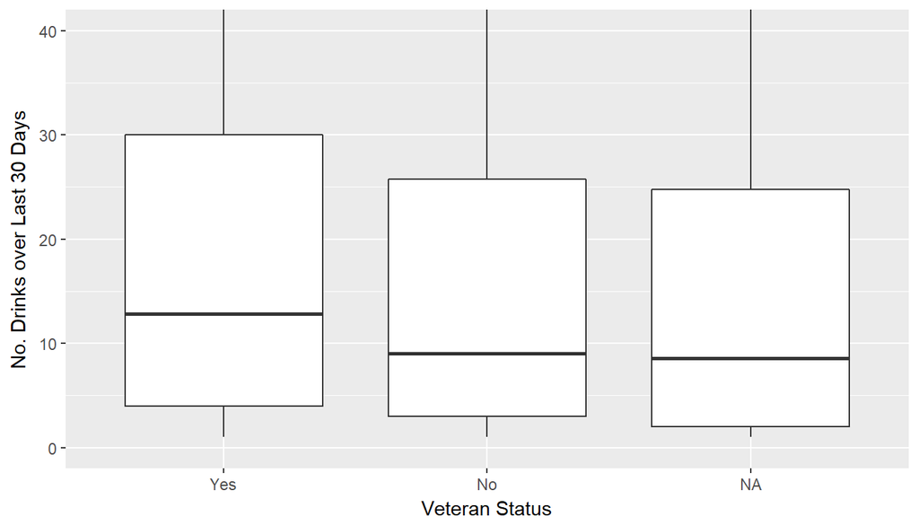

```r
ggplot(brfss2013, aes(x=veteran3, y=drinks30days)) + geom_boxplot() + coord_cartesian(ylim=c(0,40)) + xlab("Veteran Status") + ylab("No. Drinks over Last 30 Days")
```

Again we see that veterans tend to consume more alcohol. However, we cannot conclude that being a veteran causes one to drink more alcohol.

### Research quesion 3

*Which states have the highest prevalence of smoking adults? In each state and US territory, we compare the percentage of respondents who currently smoke cigarettes.*

The variable `_rfsmok3` documents adults who are current smokers: it takes the value “Yes” for a respondent who currently smokes some or all days, and “No” for a respondent who is a former smoker, or never smoked. Let’s examine the values of `_rfsmok3`:

```r
brfss2013 %>%
  group_by(X_rfsmok3) %>%
  summarize(count = n())
```

```
## # A tibble: 3 x 2
##   X_rfsmok3  count
##   <fct>      <int>
## 1 No        399786
## 2 Yes        76654
## 3 <NA>       15335
```

To compare smoking rates, we convert `_rfsmok3` to 1 for “Yes,” and 0 for “No”:

```r
brfss2013  = brfss2013 %>%
  mutate(X_rfsmok3 = ifelse(X_rfsmok3 == "Yes", 1, 0))
```

Let’s check `_rfsmok3` again:

```r
brfss2013 %>%
  group_by(X_rfsmok3) %>%
  summarize(count = n())
```

```
## # A tibble: 3 x 2
##   X_rfsmok3  count
##       <dbl>  <int>
## 1        0. 399786
## 2        1.  76654
## 3       NA   15335
```

Looks correct. Now to address our research question, we compare the current smoking rates in each state by computing the mean of `_rfsmok3`, grouped by state and sorted in descending order by smoking prevalence:

```r
smokers_by_state = brfss2013 %>%
  filter((X_state != 0) & (X_state != 80)) %>% # Filter out extraneous X_state values
  group_by(X_state) %>%
  summarize(fraction_current_smokers = mean(X_rfsmok3, na.rm=TRUE)) %>%
  arrange(desc(fraction_current_smokers))

smokers_by_state
```

```
## # A tibble: 53 x 2
##    X_state       fraction_current_smokers
##    <fct>                            <dbl>
##  1 West Virginia                    0.238
##  2 Guam                             0.237
##  3 Kentucky                         0.224
##  4 Tennessee                        0.215
##  5 Ohio                             0.206
##  6 Alaska                           0.206
##  7 Missouri                         0.198
##  8 Arkansas                         0.197
##  9 Oklahoma                         0.193
## 10 Mississippi                      0.187
## # ... with 43 more rows
```

Let’s visualize the results in a barplot:

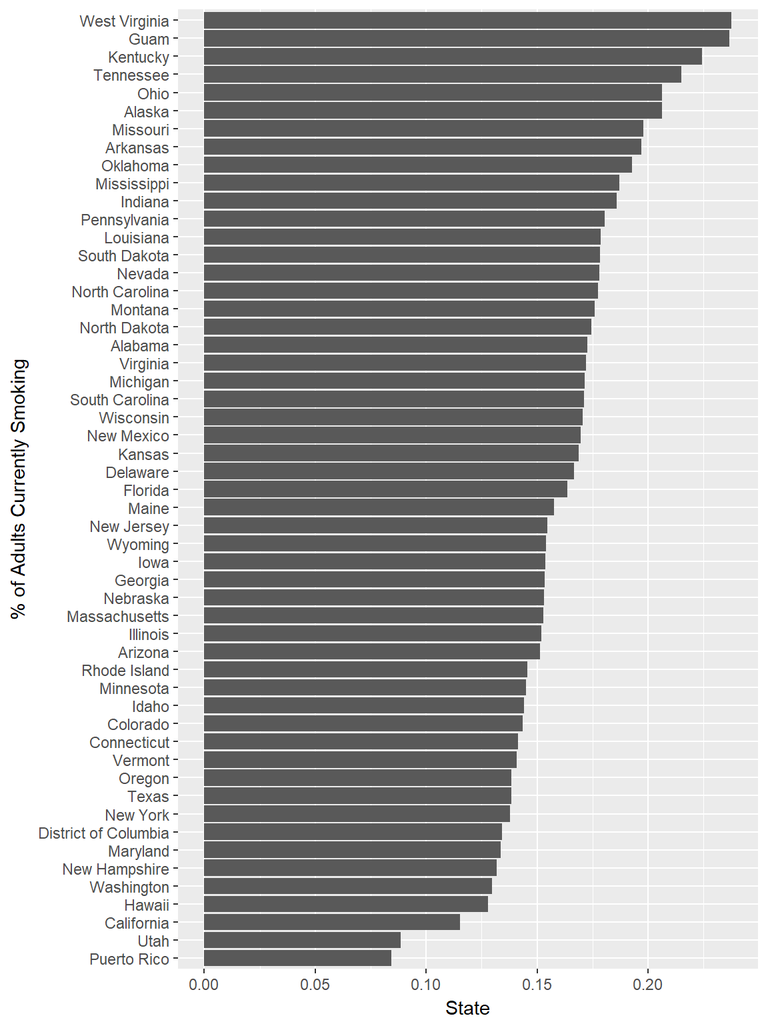

```r
ggplot(smokers_by_state, aes(x=reorder(X_state, fraction_current_smokers), y=fraction_current_smokers)) + geom_col() + coord_flip() + xlab("% of Adults Currently Smoking") + ylab("State")
```

We’ve learned that the five states with the highest rates of smoking are West Virginia, Guam (a US territory), Kentucky, Tennessee, Ohio, and the five states with the lowest rates of smoking are Puerto Rico (a US territory), Utah, California, Hawaii, and Washington state.